# Outline of and Rubric for ECON370 Final Project

Jiaxi Li

University of North Carolina | [ECON 370](https://github.com/JiaxiLi1995/ECON370)

# Final Project Instructions

The final project aims to apply everything we learn about coding, data wrangling and data analysis. You will estimate and evaluate the **prediction model** using **monthly S&P 500 index returns** from **1985** to **2024** (40 years). The final report would be done using this Rmd template and knitted into html.

You will work progressively throughout the semester, applying key concepts learned in class.

A **base model** is provided below, but you are expected to enhance it with additional variables (You are required to have **at least 10 variables** from **at least 4 different sources** for prediction), advanced modeling techniques, and insightful analysis.

The **raw data**, before any cleaning, must be reproducible directly using your R code with **standard R functions**, **without requiring an API** (for example, `tidyquant` package). If you obtain data through an API or another external method, please **upload the raw data as a CSV file to GitHub** and have your R code **load the raw data from there**. You must include all your data cleaning code and procedures in the final report.

We will talk about how to work with GitHub data when we go over presentation template.

The final deliverable includes: - One Rmd file and corresponding knitted html file using this template - The files need to provide the **full** workflow/code needed to replicate your results and your analysis step by step. - A short (~7 slide) **in-person presentation** during the scheduled final exam period.

No group work! You need to write your project details in this Rmd template and knit it into html as final project report. To ensure smooth grading, the final project Rmd and corresponding html are due 11:59PM December 9th, 2025.

Presentations should be written using RMarkdown but you are not required to turn it in. Scheduled final exam period: 8:00AM - 11:00AM, Thursday, December 11, 2025.

I describe each component in detail below. As a general rule: if you have questions, please ask them. If you feel lost, *please come to my office hours*. I am more than happy to be a resource for you and help you through problems as they arise.

Note: LLMs are *allowed* on your final project. Please include information (an extra slide in your presentation at the end) about what you used the LLM to do!

## Project Requirements

Your project should include:

1. **Data Acquisition and Preparation**
   - Collect data from multiple sources.
   - Clean, merge, and wrangle datasets appropriately.
   - Provide clear visualizations of the raw data.
   - Deal with missing data and mixed frequency.
   - Avoid **forward-looking bias** by appropriately lagging predictors.
2. **Modeling**
   - Use **linear regression** provided as a baseline model.
   - Include **at least one more sophisticated model** (e.g., regularization, neural network, tree-based methods).
3. **Model Evaluation**
   - Split the data into **training, validation, and testing sets** and apply **expending windows**.
   - Compare empirical results across models.
   - Include appropriate visuals to illustrate performance differences.
4. **Presentation**
   - Present the project in a clear, organized, and professional manner.
5. **Final Report**
   - Written Rmd and html report with logical structure and visual support.

## Rubric

Your final project will be graded out of **200 points**, broken down into **five categories**:

| **Category** | **Criteria** | **Points** |
| --- | --- | --- |
| **Conceptual Understanding** | Data acquisition is complete and relevant | 10 |
|  | Reasonable and well-justified model(s) | 15 |
|  | Clear explanation of variable selection and treatment (including lagging to prevent forward-looking bias) | 15 |
|  | Suitable exploratory analysis | 10 |
|  | Thoughtful comparison with baseline model | 10 |
| **Subtotal** |  | **60** |
| **Coding** | Code achieves project objectives correctly | 15 |
|  | Code runs without errors | 15 |
|  | Good programming practices (modular, efficient, reproducible) | 15 |
|  | Clear and appropriate comments | 10 |
|  | Code is logically organized and easy to follow | 5 |
| **Subtotal** |  | **60** |
| **Presentation (in-class)** | Clear, confident delivery and ability to answer questions | 5 |
|  | Introduction and motivation for the project | 5 |
|  | Clear and informative data slide | 5 |
|  | Explanation of model design and reasoning | 5 |
|  | Comparison with baseline model | 5 |
|  | Conclusion summarizing findings | 5 |
| **Subtotal** |  | **30** |
| **Final Report** | in Rmd and knitted into html | 5 |
|  | Logical flow through topics | 10 |
|  | Justification for variable choices and treatments | 15 |
|  | Analysis with tables and graphs | 10 |
|  | At least 1 advanced model beyond linear regression | 10 |
| **Subtotal** |  | **50** |
| **Total** |  | **200** |

**Note:** Think of your in-class presentation as a discussion of “here’s what I did and how is it better than the base model”. Your project report should additionally answer “here’s why I did what I did, also more detailed documentation of procedures.”

## Extra Credit Opportunities

You can earn extra points for:

- Using a **more sophisticated modeling approach** (+10 pts)
- Achieving the **highest out-of-sample $R^2$** among peers (+20 pts)
- **Peer voting**:
  - Coolest variable selection (no self-votes) (+10 pts)
  - Coolest model (no self-votes) (+10 pts)
- Points will be split evenly in the event of ties.

## Grading

- **TA Grading:** Whether your code runs correctly and is well-commented.
- **Instructor Grading:** Content of your project and quality of presentation.

## Final Notes

The goal of this project is to develop a **predictive modeling workflow** from start to finish. By the end, you should demonstrate your ability to **collect data**, **understand a model**, **evaluate performance**, and **communicate findings** effectively.

# Finding the Data

For return data, you can use the code in class or the code in the base model.

Finding data stinks. Below, I’ve tried to list every public data source I can think of. If nothing here appeals to you, come to my office hours and we can try to figure out how to find data on something that does interest you!

### **General Economic Research**

- [FRED](https://fred.stlouisfed.org/) – Federal Reserve Economic Data

  Phenomenal resource. I’d recommend viewing datasets by popularity.
- [Bureau of Labor Statistics (BLS)](https://www.bls.gov/data/) – Employment, productivity, inflation, wages
- [Penn World Table](https://www.rug.nl/ggdc/productivity/pwt/) – International macroeconomic data
- [NBER](https://back.nber.org/releases/) – Releases and leading indicators

### **Financial Econometrics**

- [Ken French Data Library](https://mba.tuck.dartmouth.edu/pages/faculty/ken.french/data_library.html) – Factor data and returns
- [Open Source Asset Pricing Data](https://www.openassetpricing.com/data/) – Academic finance datasets
- [Global Factor Data](https://jkpfactors.com/) – International factor datasets
- [WRDS](https://wrds.wharton.upenn.edu/) – Subscription-based professional database
- [Fed](https://www.federalreserve.gov/data.htm) - download data from Federal Reserve

### **Additional Public Data Resources**

- [Data.gov](https://data.gov/) – U.S. government open data

  Maintained by the Federal Reserve Board of St. Louis, has incredible data on mostly macro-economic time-series. Likely a source for additional data for you.
- [UNC Libraries Data Services](https://library.unc.edu/data/research-analysis/) – UNC-specific resources and subscriptions

  We have an economics department affiliated data person as well. Her name is Nancy Lovas. She will come and give a short presentation about library data source on 10/9. Let me know if you’d like me to put you in contact with her.
- [Kaggle Datasets](https://www.kaggle.com/datasets) – **Strict requirement**: speak with me before using Kaggle data

  Also a great place for you to practice data science coding in general!
- [ICPSR](https://www.icpsr.umich.edu/web/pages/ICPSR/index.html) – Large repository, mostly U.S.-based data
- [Google Public Data Explorer](https://www.google.com/publicdata/directory) – Visualization-ready datasets
- [IPUMS](https://www.ipums.org/) – Surveys on demographics, prices, time use, higher education, health, etc.

> **Note:** Ensure that all data sources are **documented clearly** in your project report and code.

# Data Processing and Analysis

It’s hard for me to be prescriptive here - what’s required of you will depend on the data you choose. In general, it is hard for me to think of a project that wouldn’t benefit from multiple data sources or datasets. Additionally, your project will almost certainly involve “cleaning” the data. To do so, you should deal with missing or incorrect information, create variables where needed, and normalize units where relevant.

Different projects will have different cleaning requirements. Please have the proper amount of cleaning totally depends on your data. Almost all datasets require *some* cleaning though.

**look-ahead bias**: Since this is a prediction task, be mindful that you can only use data available to the date for prediction. For example, the Q1 US GDP growth rate is labeled to be at the end of march, but it is not announced until Thursday, September 25, 2025! If you are predicting April returns, you cannot use this number.

In general, if you are uncertain about the announcement lag (if there is any), you can use this rule for finance/econ data: 1 month lag for monthly data, 4 month lag for quarterly data and 6 month lag for annual data. Therefore,to predict returns at month $t+1$, you can use most recent monthly data at the end of month $t-1$, most recent quarterly data by end $t-4$, and most recent annual data by end $t-6$.

Note that there are real-time information which do not require lag, such as prices (asset prices or portfolio prices). Therefore, if you are trying to use March return to predict April return, you do not need to lag it!

**training, validation and test**: For machine learning model estimations in general, we need to divide data into training, validation and test sets:

- Training set: We use this set to estimate the model parameters.
- Validation set: We use this set to select the tuning parameters for machine learning models.
- Testing set: We use this set to evaluate the model.

**Missing data**: There are different ways to address missing data. You can use historical mean, the previously observed value, or some other advanced techniques to do it. You can use previously observed value for simplicity.

**Mixed frequency**: We are trying to predict monthly returns, but variables like GDP growth rate is a quarterly data. There are different ways to deal with mixed frequency too. You can use previously observed value for simplicity.

That means, if we see 1.2% GDP growth rate for March (Q1) and 1.5% GDP growth rate for June (Q2), we can fill in 1.2% for April and May.

# Base model

Here, I will use a linear regression model to illustrate this. I will only have *GDP growth rate* and *current monthly SP500 return* as predictors for *next month SP500 return*. You are required to have at least 10 variables for prediction and use more advanced model than linear regression.

This base model will also be the model you should beat with more variables and more sophisticated models. Make sure you compare the prediction accuracy between your model and the base model!

## Variable Reasoning

If the economy is in good shape, it would provide more business opportunities. People would be willing to invest in stocks and the stock price would be higher, achieving higher returns. Therefore, *GDP growth rate* might be a useful predictor for stock returns.

There are some momentum reasoning for using past return to predict future return. If the stock market is performing well, more people would buy it and price is pushed higher, achieving higher returns.Therefore, *lagged monthly SP500 return* might be a useful predictor for stock returns.

Note that returns is a rate, we need to use rate to predict it. Instead of GDP level, I would use *GDP growth rate* here. *It is generally a bad idea to use level to predict rate!*

## Data Extraction, Cleaning and Combining

Now, we need to work with data cleaning. We need to fill in in-between-quarter months values and we need to deal with look-ahead of bias for GDP growth rate. For simplicity, so we will fill in the previously observed value for in-between-quarter months and lag observations by 4 months for prediction.

The model would not start on January 1985. But to predict the return on January 1985, we will need the GDP growth rate from 1984. This means that you need to extract prediction variables starting probably 1984, or even earlier!

```r
# Data for prices, I would like to extract slightly before 1985
library(tidyquant)
library(dplyr)
library(tidyr)
library(lubridate)
library(ggplot2)
# Get S&P500 daily data
SP500_simple_returns = tq_get("^GSPC",
                               from = "1984-01-01",
                               to   = "2024-12-31",
                               get  = "stock.prices") |>
  tq_transmute(
    select     = adjusted,       # adjusted price for accuracy
    mutate_fun = periodReturn,   # calculate period returns
    period     = "monthly",      # monthly returns
    type       = "arithmetic",   # simple return (percentage change)
    col_rename = "monthly_return"
  ) |>
  mutate(monthly_return = monthly_return*100) # Convert to percentage

head(SP500_simple_returns)
```

```
## # A tibble: 6 × 2
##   date       monthly_return
##   <date>              <dbl>
## 1 1984-01-31         -0.384
## 2 1984-02-29         -3.89
## 3 1984-03-30          1.35
## 4 1984-04-30          0.547
## 5 1984-05-31         -5.94
## 6 1984-06-29          1.75
```

```r
# We can use tq_get to get FRED data as well!
# Download real GDP data from FRED
# You can go to FRED to find what the symbol is for GDP growth rate
gdp_data = tq_get("A191RL1Q225SBEA",
                   get  = "economic.data",
                   from = "1984-01-01") # start date

head(gdp_data)
```

```
## # A tibble: 6 × 3
##   symbol          date       price
##   <chr>           <date>     <dbl>
## 1 A191RL1Q225SBEA 1984-01-01   8.1
## 2 A191RL1Q225SBEA 1984-04-01   7.1
## 3 A191RL1Q225SBEA 1984-07-01   3.9
## 4 A191RL1Q225SBEA 1984-10-01   3.3
## 5 A191RL1Q225SBEA 1985-01-01   3.9
## 6 A191RL1Q225SBEA 1985-04-01   3.6
```

**Be careful** about the GDP growth rate! The variable name is `price` somehow, so we need to correct it. It is labeled 1984-01-01 for Q1 of 1984. However, we should put it at the quarter end, which should be labeled at the end of March! We need to move the dates 2 month forward.

```r
# Correct GDP growth rate name and date to quarter end
gdp_data = gdp_data |>
  rename(GDP_g = price) |>
  mutate(date = date %m+% months(2))
```

You can see that SP500_simple_returns has the date to be month end, but gdp_data has the date to be month begin. There are several ways to deal with this. One way is to use `floor_date(d, unit = "month")` from `lubridate` to make the date to be month begin.

```r
# Use left join to join gdp data to SP500 returns
Total_data = SP500_simple_returns |>
  mutate(date = floor_date(date, unit = "month")) |>
  left_join(gdp_data)

head(Total_data)
```

```
## # A tibble: 6 × 4
##   date       monthly_return symbol          GDP_g
##   <date>              <dbl> <chr>           <dbl>
## 1 1984-01-01         -0.384 <NA>             NA
## 2 1984-02-01         -3.89  <NA>             NA
## 3 1984-03-01          1.35  A191RL1Q225SBEA   8.1
## 4 1984-04-01          0.547 <NA>             NA
## 5 1984-05-01         -5.94  <NA>             NA
## 6 1984-06-01          1.75  A191RL1Q225SBEA   7.1
```

I will use a simple approach to make the quarterly data monthly, that is use the early values fill the in-between months. We can achieve this by using `fill` from `tidyr`.

```r
# Fill the GDP_g downward
Total_data = Total_data |>
  tidyr::fill(GDP_g, .direction = "down") |>
  # We do not need the symbol
  select(-symbol)

head(Total_data)
```

```
## # A tibble: 6 × 3
##   date       monthly_return GDP_g
##   <date>              <dbl> <dbl>
## 1 1984-01-01         -0.384  NA
## 2 1984-02-01         -3.89   NA
## 3 1984-03-01          1.35    8.1
## 4 1984-04-01          0.547   8.1
## 5 1984-05-01         -5.94    8.1
## 6 1984-06-01          1.75    7.1
```

```r
# Lag GDP_g further by 4 months
Total_data = Total_data |>
  mutate(GDP_g = lag(GDP_g, 4))

head(Total_data)
```

```
## # A tibble: 6 × 3
##   date       monthly_return GDP_g
##   <date>              <dbl> <dbl>
## 1 1984-01-01         -0.384    NA
## 2 1984-02-01         -3.89     NA
## 3 1984-03-01          1.35     NA
## 4 1984-04-01          0.547    NA
## 5 1984-05-01         -5.94     NA
## 6 1984-06-01          1.75     NA
```

Now, it is time to establish the variable to predict and corresponding predicting months. At 1984-01-01, we would try to predict returns on 1984-02-01, which means we need to create a column of predicting values using `lead`.

```r
# Creating predicting_date and predicting_return using lead
Total_data = Total_data |>
  mutate(predicting_date = lead(date),
         predicting_return = lead(monthly_return))

head(Total_data)
```

```
## # A tibble: 6 × 5
##   date       monthly_return GDP_g predicting_date predicting_return
##   <date>              <dbl> <dbl> <date>                      <dbl>
## 1 1984-01-01         -0.384    NA 1984-02-01                 -3.89
## 2 1984-02-01         -3.89     NA 1984-03-01                  1.35
## 3 1984-03-01          1.35     NA 1984-04-01                  0.547
## 4 1984-04-01          0.547    NA 1984-05-01                 -5.94
## 5 1984-05-01         -5.94     NA 1984-06-01                  1.75
## 6 1984-06-01          1.75     NA 1984-07-01                 -1.65
```

Now, you can see everything is lined up! We are using information available on 1984-01-01 (which is actually the end of January 1984) to predict return on 1984-02-01 (which is the February 1984 monthly returns). We will establish predictive model from 1985 to 2024, so we will only need the data with predicting date from 1985-01-01 to 2024-12-01. Let’s subset that:

```r
# Subset predicting date from 1985-01-01 to 2024-12-01
# MAKE SURE IT IS predicting_date!
Total_data = Total_data |>
  filter(predicting_date >= "1985-01-01",
         predicting_date <= "2024-12-01")

# see the first and last 3 observations
head(Total_data, n = 3)
```

```
## # A tibble: 3 × 5
##   date       monthly_return GDP_g predicting_date predicting_return
##   <date>              <dbl> <dbl> <date>                      <dbl>
## 1 1984-12-01          2.24    7.1 1985-01-01                  7.41
## 2 1985-01-01          7.41    3.9 1985-02-01                  0.863
## 3 1985-02-01          0.863   3.9 1985-03-01                 -0.287
```

```r
tail(Total_data, n = 3)
```

```
## # A tibble: 3 × 5
##   date       monthly_return GDP_g predicting_date predicting_return
##   <date>              <dbl> <dbl> <date>                      <dbl>
## 1 2024-09-01          2.02    0.8 2024-10-01                 -0.990
## 2 2024-10-01         -0.990   3.6 2024-11-01                  5.73
## 3 2024-11-01          5.73    3.6 2024-12-01                 -2.08
```

Based on the first and last three observations, we can confirm that we are prediciting returns from 1985-01-01 to 2024-12-01.

Now, it is a good time to check whether we have any missing data by `is.na`:

```r
# Check if there is any NA in the data
anyNA(Total_data)
```

```
## [1] FALSE
```

Great! No missingness! If there is, you can use `tidyr::fill` again to fill it up.

# Exploration of raw data

Here are just some exploration about the relationship each of our predictors and the predicting_return. I will demonstrate two things:

1. Does the variable I choose have a relationship with the predicting_return?
2. Is this relationship changing over time?

For both, I will use `cor` to calculate the pairwise correlation between variables. To examing whether the relationship is changing, I will use a rolling correlation and plot how the relationship evolute overtime.

**Correlation**

```r
# Correlation works between vectors. We can do vectorization with matrix here.
cor(Total_data$predicting_return, Total_data[, c("monthly_return", "GDP_g")])
```

```
##      monthly_return       GDP_g
## [1,]    0.001383613 0.007191952
```

**Rolling Correlation**

I will conduct 5-year rolling window correlations between predicting_return and other variables. I will use the predicting_date of the end of 5-year window as the date for correlation. We can use `for` loop to do the calculation.

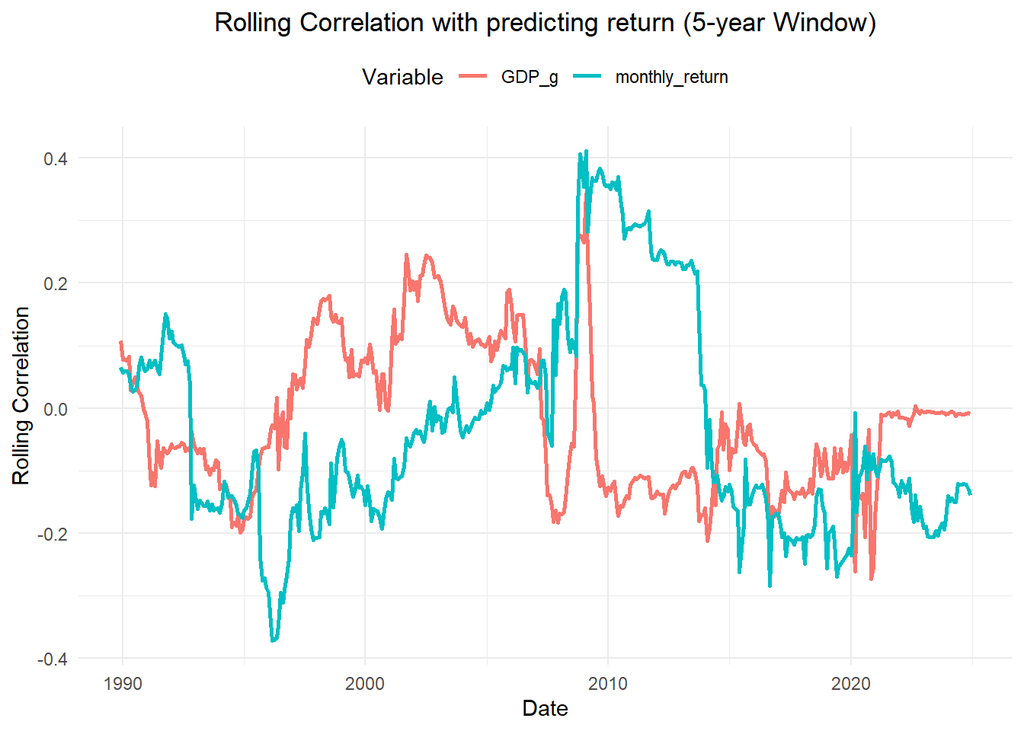

```r
# Preallocate the result, same shape as Total_data, no predicting_return and no date
Rolling_corr = Total_data |>
  select(-c("predicting_return", "date"))

# Variable_names (all names except "predicting_date", use logical indexing)
Variable_names = names(Rolling_corr)[names(Rolling_corr) != "predicting_date"]

# Make all the variables to NA as part of preallocate
Rolling_corr[,Variable_names] = NA

# A for loop to calculate the rolling correlations, vectorize inside loop
# 5-year correlation or 60 months
# The first window would be 1st to 60th (1+59) row, and last would be (nrow(Rolling_corr)-59)-th to nrow(Rolling_corr)-th row
for (i in 1:(nrow(Rolling_corr)-59)) {
  Rolling_corr[i+59, Variable_names] = cor(Total_data[i:(i+59), "predicting_return"], Total_data[i:(i+59), Variable_names])
}

# Note there are 59 rows of NA's due to the rolling window

# We need to make the table to a long table and then use ggplot to plot the rolling correlation
Rolling_corr |>
  # Remove the missing rows
  na.omit() |>
  # Except predicting_date, make this a long table,
  pivot_longer(-predicting_date,
               names_to = "Variable",
               values_to = "rolling_corr") |>
  ggplot(aes(x = predicting_date, y = rolling_corr, color = Variable)) +
  geom_line(linewidth = 1) +
  theme_minimal() +
  labs(
    title = "Rolling Correlation with predicting return (5-year Window)",
    x = "Date",
    y = "Rolling Correlation",
    color = "Variable"
  ) +
  theme(
    legend.position = "top",
    plot.title = element_text(hjust = 0.5)  # <-- Center the title
  )
```

It seems that the relationship is changing over time. It is better to have a rolling window/expanding window to do the prediction. I will choose an expanding window and require you to use an expanding window. This is just make it easier to compare everyone’s result.

I just did correlation, you can explore more aspects if you would like.

## Linear Model Estimation

This section, we will finally estimate the linear model. Remember that we should have an expanding window, split the dataset into training, validation and testing. However, since linear model does not have tuning parameters, we would just put the validation set into training set: - 1985-2008 as training, and 2009 to evaluate the model - 1985-2009 as training, and 2010 to evaluate the model … - 1985-2023 as training, and 2024 to evaluate the model

```r
# Preallocate the fitted data from 2009 to 2024
Testing_result = Total_data |>
  filter(predicting_date >= "2009-01-01") |>
  # Only keep the predicting_date, predicting_return, and create fitted_return
  select(predicting_date, predicting_return) |>
  rename(actual_return= predicting_return) |>
  mutate(fitted_return = NA)


# Use a for loop to estimate each model and lm for linear regression
# Start from the end year 2008 to 2023 which are the end of training periods
for (i in 2008:2023) {
  # Extract the Training data
  Training_data = Total_data |>
    # before i+1 year
    filter(year(predicting_date) < i+1) |>
    # Only keep the predictors and the predicting_return
    select(c(predicting_return, all_of(Variable_names)))

  # Estimate the model
  Model = lm(predicting_return ~ ., data = Training_data)

  # New data to predict
  Testing_data = Total_data |>
    # at i+1 year
    filter(year(predicting_date) == i+1) |>
    # Only keep the predictors
    select(all_of(Variable_names))

  # Make predictions and save to year i+1 using logical indexing
  # Use predict to estimate the fitted data based on model and test data
  Testing_result[year(Testing_result$predicting_date) == i+1, "fitted_return"] = predict(Model, newdata = Testing_data)
}
```

## Analyze the Result

Now, let’s look at how the predicted return and actual return are related.

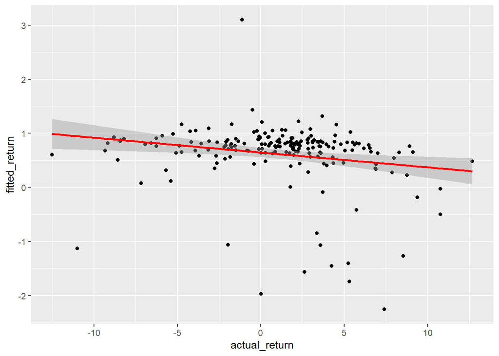

```r
Testing_result |>
  ggplot(aes(actual_return, fitted_return)) +
  geom_point() +
  geom_smooth(method = "lm", se = TRUE, color = "red")  # Fitted regression line
```

```r
# # Save the result
# saveRDS(Testing_result, "Testing_result.rds")
```

If the fitting is good, we should have fitted_return to be roughly equal to actual_return. The line should be around slope 1.

The linear model performs extremely poorly here!

Estimate the out of sample $R^2$ ($R^2_{OOS}$, based on the testing period). Usually, we assume the return to be 0 average. The R squared for return is defined as:

$$R^2_{OOS} = 1-\frac{\sum(y_{actual} - y_{predict})^2}{\sum y_{actual}^2}$$

The closer it is to 1, the better the prediction accuracy.

```r
# calculate OOS r squared based on the formula
R_sq_oos = 1 - sum((Testing_result$actual_return - Testing_result$fitted_return)^2)/sum((Testing_result$actual_return)^2)
R_sq_oos
```

```
## [1] -0.02238912
```

We get negative out of sample $R^2$! If we predict 0, we would get $R^2_{OOS} = 0$, so the linear model is doing a worse job than just simply guessing 0 return!

We can further explore which years are doing the worst and which years the model is fine. Let’s calculate the $R^2_{OOS}$ based on every 4 years. (Use 4 years is to have sufficient amount of data to estimate the $R^2_{OOS}$, while having several periods for comparison.)

```r
# Create a function to estimate R_Sq_oos
R_Sq_oos_func = function(actual_return, fitted_return) {
  return(1 - sum((actual_return - fitted_return)^2)/sum((actual_return)^2))
}

# Estimate every 4-year R_sq_oos
R_sq_oos_table = Testing_result |>
  # first break the dates into 4 year periods
  mutate(
    year = year(predicting_date),
    period_4yr = cut(year, breaks = seq(min(year), max(year) + 3, by = 4), right = FALSE)
  ) |>
  group_by(period_4yr) |>
  summarise(R_Sq_oos = R_Sq_oos_func(actual_return, fitted_return))

R_sq_oos_table
```

```
## # A tibble: 4 × 2
##   period_4yr  R_Sq_oos
##   <fct>          <dbl>
## 1 [2009,2013)  -0.0702
## 2 [2013,2017)   0.0552
## 3 [2017,2021)   0.0134
## 4 [2021,2025)  -0.0400
```

The goodness of fit is good during 2013-2016. It is not good right after crashes (2008 and 2020). Period 2017-2020 contains crash during Covid (year 2020) and that might be the cause of low predictability.

To verify that, let’s calculate $R^2_{OOS}$ for 2017-2019, before the covid crash:

```r
# Get the logical index for 2017 to 2019
Ind_17_19 = year(Testing_result$predicting_date)<=2019 & year(Testing_result$predicting_date)>=2017
# We can just apply R_Sq_oos_func function
R_Sq_oos_func(Testing_result$actual_return[Ind_17_19], Testing_result$fitted_return[Ind_17_19])
```

```
## [1] 0.05422062
```

Here, we verified our conjecture that the linear model is actually doing okay during normal times. This number is close to the 2013-2016 period.

**Note that different model might perform differently during different times.**

## A Simple Trading Strategy Based on the Simple Model

The actual meaning of such predictive model is that we can implement trade on it! (You can think of this as a way to evaluate the predictive model. The more money we can make, the better the model is.)

For example, let’s have a strategy that: - We buy/hold the SP500 index if we predict positive returns next month. - We sell/not buy the SP500 index if we predict negative/zero returns next month.

In reality, you can choose a more complicated threshold for buying/selling. Or even allow short selling. For demonstration purpose, we will stick to the simplest one.

To see whether our combination of predictive model and trading strategy is effective, we will compare our linear model + simple strategy’s cumulative return (buyLMpositive) vs. buy and hold cumulative return (buyANDhold):

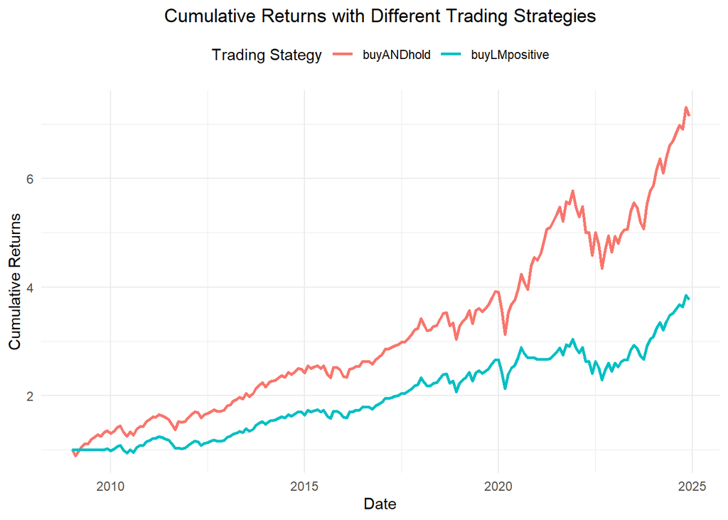

```r
# Create a dataset for trading strategy comparison: buyLMpositive vs. buyANDhold
Trading_Strategy = Testing_result |>
  # Create a logical index of whether we realize the monthly return based on our trading strategy
  mutate(Trade = (fitted_return > 0)) |>
  # Create a buyLMpositive strategy
  mutate(buyLMpositive_ret = Trade*actual_return)


# Now, use for loop to calculate the cumulative gross returns
# Preset the two strategy
Trading_Strategy$buyLMpositive = NA
Trading_Strategy$buyLMpositive[1] = 1
Trading_Strategy$buyANDhold = Trading_Strategy$buyLMpositive

# Loop
for(i in 2:nrow(Trading_Strategy)) {
  Trading_Strategy$buyLMpositive[i] = Trading_Strategy$buyLMpositive[i-1] * (1+Trading_Strategy$buyLMpositive_ret[i]/100)
  Trading_Strategy$buyANDhold[i] = Trading_Strategy$buyANDhold[i-1] * (1+Trading_Strategy$actual_return[i]/100)
}

# Plot the cumulative returns
# Only select buyLMpositive and buyANDhold; and make the data longer
Trading_Strategy |>
  pivot_longer(c(buyLMpositive, buyANDhold), names_to = "Strategy", values_to = "CR") |>
  ggplot(aes(predicting_date, CR, color = Strategy)) +
  geom_line(linewidth = 1) +
  theme_minimal() +
  labs(
    title = "Cumulative Returns with Different Trading Strategies",
    x = "Date",
    y = "Cumulative Returns",
    color = "Trading Stategy"
  ) +
  theme(
    legend.position = "top",
    plot.title = element_text(hjust = 0.5)  # <-- Center the title
  )
```

```r
# # Save the result
# saveRDS(Trading_Strategy, "Trading_Strategy.rds")
```

We can see that the simple trading strategy + the LM predictive model is performing much worse than simply buy and hold the SP500 index!

**Now, it is your turn to use some awesome data and better methods to predict better!**

# Presentations

Your final project will consist of the code and analysis in Rmd, corresponding knitted html file, and a short presentation created by another Rmd. The presentation will be a 7-slide, 7-minute presentation you deliver during our scheduled exam time. The project report will be a final work product.

The Rmd file, your final work product, needs to be more involved. In it, I’d like you to be more explicit about your project: show us what the data looks like (summary statistics etc.), what kind of cleaning you did, what is the model you use and the result, and so on.

I’d like the presentations to be knitted by RMarkdown with the provided template.